# Forecasting US Energy Consumption

Shivani Tyagi March 24, 2022

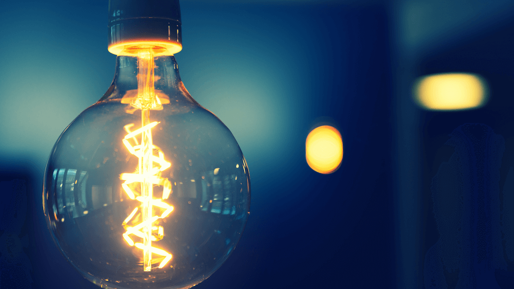

## Goal:

The goal of this project is to build a model to forecast the US energy consumption.

## About Data

The data is downloaded from the eia’s website which is a U.S Energy Information Administration and does independent Statistics and Analysis.

https://www.eia.gov/totalenergy/data/browser/xls.php?tbl=T02.01&freq=m

## Importing Modules

```r
install.packages("rlang", repos = "http://cran.us.r-project.org")
install.packages("fpp3", repos = "http://cran.us.r-project.org")
install.packages("readxl", repos = "http://cran.us.r-project.org")
install.packages("tsibble", repos = "http://cran.us.r-project.org")
library(fpp3)
library(tsibble)
library(readxl)
library(dplyr)
library(knitr)
```

```r
#Clearing variables
rm(list=ls())
```

## EDA

```r
#Reading Data
data <-read_excel("D:/D_ST/VCU/Spring 2022/DAPT-632 Forecasting/Case/Total Energy Consumption.xlsx")
```

```r
#Converting to a tsibble
data$Month = yearmonth(data$Month)
data <- as_tsibble(data, index = Month )
```

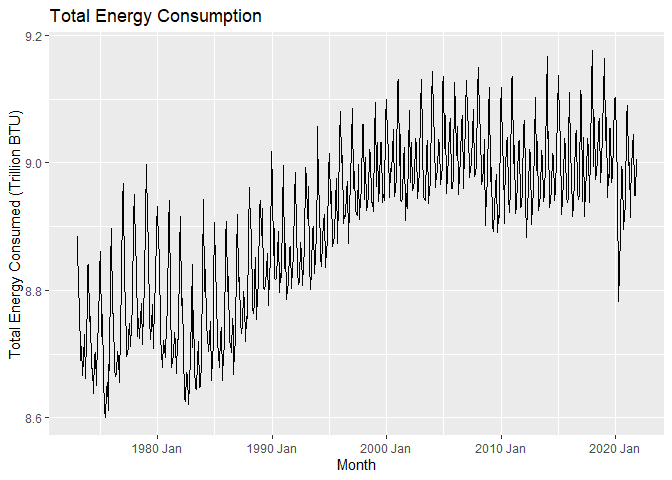

```r
#Visualize Data
data %>%
  autoplot(log(TotalEnergyConsumption)) +
  xlab("Month") +
  ylab("Total Energy Consumed (Trillion BTU)") +
  ggtitle("Total Energy Consumption")
```

It can be seen from the above graph that Energy consumption has a increasing Trend and have monthly seasonality. From year 2000 to 2021 the trend seems to damped which is because energy industry is changing very fast as more renewable energy coming into picture and there have been several national energy-efficiency policy coming into place.

Since, Energy Consumption changed drastically over time period, let’s consider data for last two decades

```r
data<- data %>%
      filter(year(Month) > 2000) %>%
      select(Month,TotalEnergyConsumption )
```

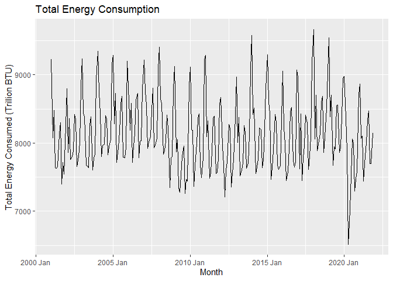

```r
#Visualize Data
data %>%
  autoplot(TotalEnergyConsumption) +
  xlab("Month") +
  ylab("Total Energy Consumed (Trillion BTU)") +
  ggtitle("Total Energy Consumption")
```

At a glance we can see that there is definitively seasonality in the Energy Consumption and it dropped drastically in month of April 2020 because of the lock down that the world saw when the Covid-19 hit. But energy consumption gradually reached the same pace as the business reopened.

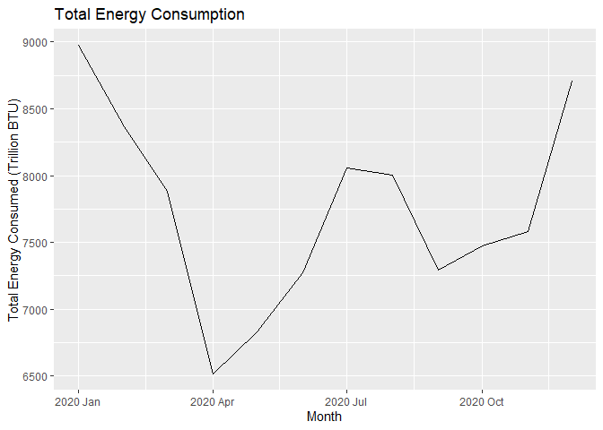

```r
#Visualize Data for 2020
data %>%
  filter(year(Month) == 2020)  %>%
  select(Month,TotalEnergyConsumption )  %>%
  autoplot(TotalEnergyConsumption) +
  xlab("Month") +
  ylab("Total Energy Consumed (Trillion BTU)") +
  ggtitle("Total Energy Consumption")
```

For year 2020, there is sudden dip in Energy Consumption for month of April and it started catching up in July.

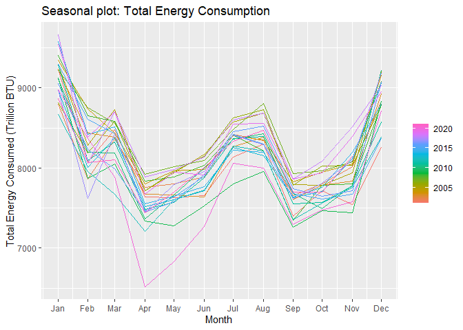

```r
#Plotting Seasonality
data %>%
  gg_season(TotalEnergyConsumption, period = "year") +
  labs(y = "Total Energy Consumed (Trillion BTU)" ,
       title = "Seasonal plot: Total Energy Consumption")
```

```r
data %>%
  gg_subseries(TotalEnergyConsumption) +
  labs(
    y = "Total Energy Consumed (Trillion BTU)",
    title =  "Seasonal SubSeries: Total Energy Consumption")
```

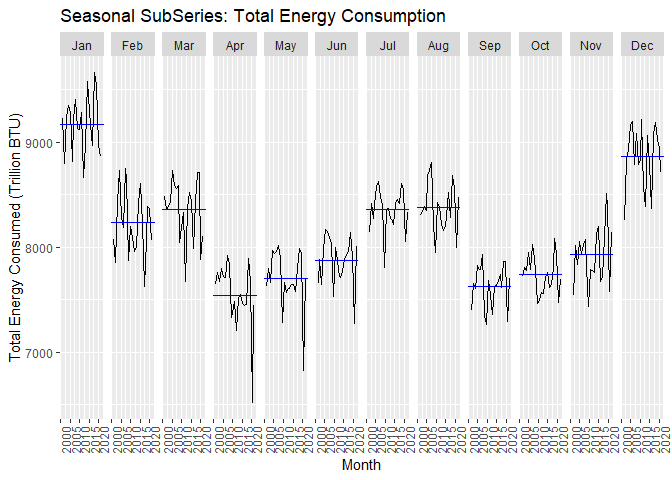

It is clear from the above gg_subseries plot that the lowest energy consumption was seen in month April, May, June of year 2020.

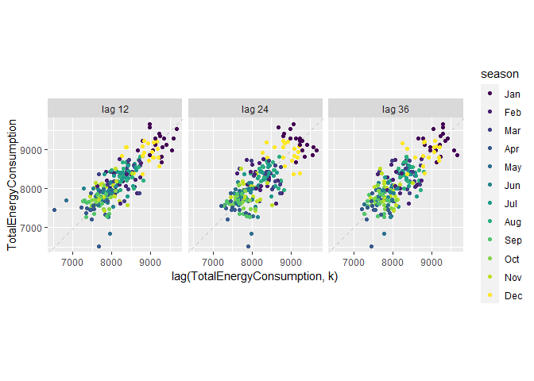

```r
#Plotting Lags
data %>%
  gg_lag(TotalEnergyConsumption, geom = "point", lags = c(12,24,36)) +
  labs(x = "lag(TotalEnergyConsumption, k)")
```

```r
data %>%
  gg_lag(TotalEnergyConsumption, geom = "point") +
  labs(x = "lag(TotalEnergyConsumption, k)")
```

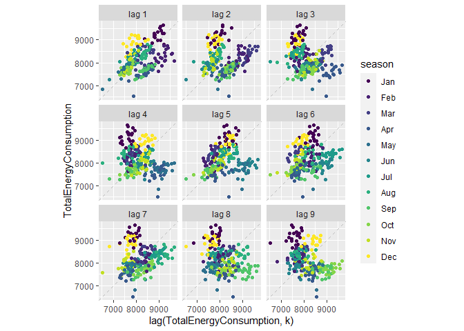

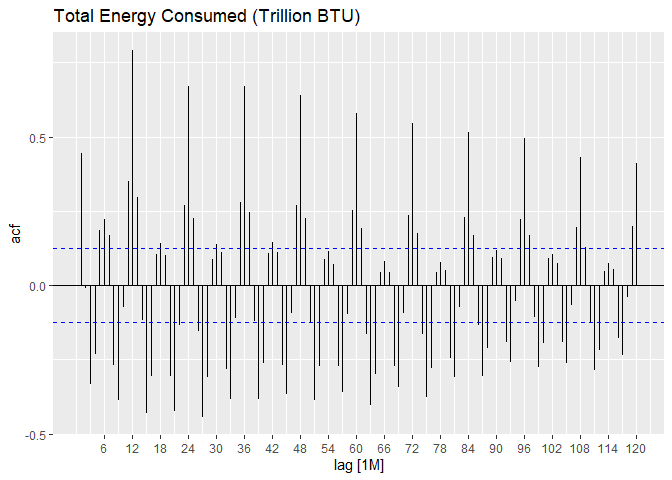

```r
# Plotting the auto Correlations
data %>%
  ACF(TotalEnergyConsumption, lag_max = 120) %>%
  autoplot() + labs(title="Total Energy Consumed (Trillion BTU)")
```

- The ACF plot there is ‘Trend’ in our data since the ACF is slowly decreasing as our lags are increasing.
- The peaks can be observed at lag 12, 24, 36 showing seasonal lags.
- The alternating(Sinusoidal) and tapering pattern suggests that there is higher order auto-regressive term in the data and a AR model will be well suited for forecasting this Time Series Data.

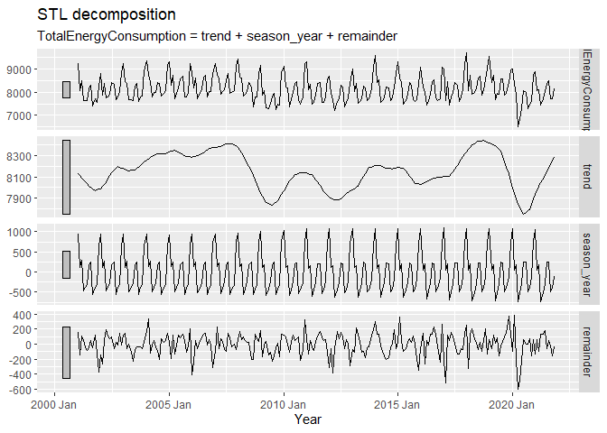

```r
#STL Without season window
dcmp <- data %>%
        model(STL(TotalEnergyConsumption))

#STL WITH SEASON WINDOW
Sdcmp <- data %>%
  model(STL(TotalEnergyConsumption ~ season(window= "periodic"), robust = TRUE))

#Plotting all components
components(dcmp) %>% autoplot() + xlab("Year")
```

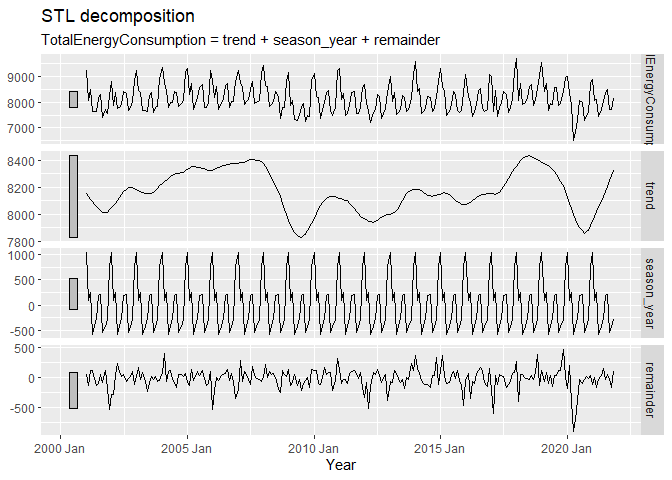

```r
components(Sdcmp) %>% autoplot() + xlab("Year")
```